# Tugas pertemuan 3 Praktikum Metode Peramalan Deret Waktu

# Tugas

# 1. Persiapan Data

## *Packages*

```r
library(dLagM)
library(dynlm)
library(MLmetrics)
library(lmtest)
library(car)
library(forecast)
```

```r
library(ggplot2)
```

## Impor & Pembagian Data

```r
# Impor Data
data <- read.csv("C:\\Users\\Mybook Hype7\\Documents\\MPDWW\\MPDWW\\Pertemuan 3\\NewDelhi_Air_quality.csv")
head(data)
```

```
##   X  AQI       CO      datetime        no2       o3      pm10     pm25
## 1 0 30.2 198.6027 2022-10-21:18 0.04685717 55.78995 10.486722 5.637410
## 2 1 28.2 197.6013 2022-10-21:19 0.04645554 54.93164 10.719325 4.618169
## 3 2 26.6 198.6027 2022-10-21:20 0.04685717 54.64554 11.155578 3.520902
## 4 3 25.0 201.9405 2022-10-21:21 0.04819594 55.07469 11.116206 2.225919
## 5 4 26.0 205.2784 2022-10-21:22 0.04886533 55.78995 10.405250 1.979471
## 6 5 26.0 208.6163 2022-10-21:23 0.05020411 56.50520  9.402518 1.792677
##         so2     timestamp_local       timestamp_utc         ts
## 1 0.3874302 2022-10-21T23:00:00 2022-10-21T18:00:00 1666375200
## 2 0.4097819 2022-10-22T00:00:00 2022-10-21T19:00:00 1666378800
## 3 0.4023313 2022-10-22T01:00:00 2022-10-21T20:00:00 1666382400
## 4 0.3762543 2022-10-22T02:00:00 2022-10-21T21:00:00 1666386000
## 5 0.3390014 2022-10-22T03:00:00 2022-10-21T22:00:00 1666389600
## 6 0.3129244 2022-10-22T04:00:00 2022-10-21T23:00:00 1666393200
```

```r
str(data)
```

```
## 'data.frame':    72 obs. of  12 variables:
##  $ X              : int  0 1 2 3 4 5 6 7 8 9 ...
##  $ AQI            : num  30.2 28.2 26.6 25 26 26 26 24 23 24 ...
##  $ CO             : num  199 198 199 202 205 ...
##  $ datetime       : chr  "2022-10-21:18" "2022-10-21:19" "2022-10-21:20" "2022-10-21:21" ...
##  $ no2            : num  0.0469 0.0465 0.0469 0.0482 0.0489 ...
##  $ o3             : num  55.8 54.9 54.6 55.1 55.8 ...
##  $ pm10           : num  10.5 10.7 11.2 11.1 10.4 ...
##  $ pm25           : num  5.64 4.62 3.52 2.23 1.98 ...
##  $ so2            : num  0.387 0.41 0.402 0.376 0.339 ...
##  $ timestamp_local: chr  "2022-10-21T23:00:00" "2022-10-22T00:00:00" "2022-10-22T01:00:00" "2022-10-22T02:00:00" ...
##  $ timestamp_utc  : chr  "2022-10-21T18:00:00" "2022-10-21T19:00:00" "2022-10-21T20:00:00" "2022-10-21T21:00:00" ...
##  $ ts             : int  1666375200 1666378800 1666382400 1666386000 1666389600 1666393200 1666396800 1666400400 1666404000 1666407600 ...
```

```r
#pemilihan variabel

datame <- data[, c("datetime", "AQI", "o3")]

head(data)
```

```
##   X  AQI       CO      datetime        no2       o3      pm10     pm25
## 1 0 30.2 198.6027 2022-10-21:18 0.04685717 55.78995 10.486722 5.637410
## 2 1 28.2 197.6013 2022-10-21:19 0.04645554 54.93164 10.719325 4.618169
## 3 2 26.6 198.6027 2022-10-21:20 0.04685717 54.64554 11.155578 3.520902
## 4 3 25.0 201.9405 2022-10-21:21 0.04819594 55.07469 11.116206 2.225919
## 5 4 26.0 205.2784 2022-10-21:22 0.04886533 55.78995 10.405250 1.979471
## 6 5 26.0 208.6163 2022-10-21:23 0.05020411 56.50520  9.402518 1.792677
##         so2     timestamp_local       timestamp_utc         ts
## 1 0.3874302 2022-10-21T23:00:00 2022-10-21T18:00:00 1666375200
## 2 0.4097819 2022-10-22T00:00:00 2022-10-21T19:00:00 1666378800
## 3 0.4023313 2022-10-22T01:00:00 2022-10-21T20:00:00 1666382400
## 4 0.3762543 2022-10-22T02:00:00 2022-10-21T21:00:00 1666386000
## 5 0.3390014 2022-10-22T03:00:00 2022-10-21T22:00:00 1666389600
## 6 0.3129244 2022-10-22T04:00:00 2022-10-21T23:00:00 1666393200
```

```r
summary(data)
```

```
##        X              AQI              CO          datetime
##  Min.   : 0.00   Min.   :19.00   Min.   :191.9   Length:72
##  1st Qu.:17.75   1st Qu.:25.00   1st Qu.:197.4   Class :character
##  Median :35.50   Median :27.00   Median :200.3   Mode  :character
##  Mean   :35.50   Mean   :26.18   Mean   :200.1
##  3rd Qu.:53.25   3rd Qu.:28.00   3rd Qu.:203.6
##  Max.   :71.00   Max.   :32.00   Max.   :208.6
##       no2                o3             pm10             pm25
##  Min.   :0.01556   Min.   :41.48   Min.   : 6.687   Min.   :1.633
##  1st Qu.:0.03799   1st Qu.:53.64   1st Qu.: 7.865   1st Qu.:1.829
##  Median :0.04552   Median :57.22   Median : 8.914   Median :2.202
##  Mean   :0.04200   Mean   :56.57   Mean   : 9.115   Mean   :2.295
##  3rd Qu.:0.05020   3rd Qu.:60.08   3rd Qu.:10.275   3rd Qu.:2.522
##  Max.   :0.06091   Max.   :68.66   Max.   :12.846   Max.   :5.637
##       so2         timestamp_local    timestamp_utc            ts
##  Min.   :0.2831   Length:72          Length:72          Min.   :1.666e+09
##  1st Qu.:0.3204   Class :character   Class :character   1st Qu.:1.666e+09
##  Median :0.3725   Mode  :character   Mode  :character   Median :1.667e+09
##  Mean   :0.3634                                         Mean   :1.667e+09
##  3rd Qu.:0.3958                                         3rd Qu.:1.667e+09
##  Max.   :0.4545                                         Max.   :1.667e+09
```

```r
# Membagi data (80% training, 20% untuk testing)
train <- datame[1:57,]
test <- datame[58:72,]

# Mengubah format data menjadi objek Time Series (ts)
train.ts <- ts(train)
test.ts <- ts(test)
data.ts <- ts(data)
```

# 2. Terapkan ketiga metode regresi

## A. Model Koyck

Model Koyck mengatasi masalah infinite distributed lag (pengaruh masa lalu yang tak terhingga) dengan mengasumsikan bahwa semakin jauh jarak lag, semakin kecil pengaruhnya.

Melalui transformasi aljabar, efek masa lalu dari X yang sangat panjang diringkas ke dalam satu variabel saja, yaitu $Y_{t-1}$. Bentuk persamaannya menjadi:

$$Y_t=a(1-\lambda)+\beta_0X_t+\lambda
Y_{t-1}+V_t$$
Catatan: $V_t$ adalah error term gabungan. Pada hasil ringkasan model (estimasi), $V_t$ tidak ditampilkan karena nilai harapannya diasumsikan nol.

### Pemodelan

Pemodelan ini menggunakan fungsi `koyckDlm()`.

```r
# Membangun Model Koyck
model.koyck <- koyckDlm(x = train$o3, y = train$AQI)
summary(model.koyck)
```

```
##
## Call:
## "Y ~ (Intercept) + Y.1 + X.t"
##
## Residuals:
##       Min        1Q    Median        3Q       Max
## -1.127670 -0.301407  0.001002  0.262601  1.103471
##
## Coefficients:
##             Estimate Std. Error t value Pr(>|t|)
## (Intercept)  0.54798    0.92878   0.590    0.558
## Y.1          0.41955    0.08223   5.102 4.63e-06 ***
## X.t          0.25830    0.04107   6.289 6.25e-08 ***
## ---
## Signif. codes:  0 '***' 0.001 '**' 0.01 '*' 0.05 '.' 0.1 ' ' 1
##
## Residual standard error: 0.5053 on 53 degrees of freedom
## Multiple R-Squared: 0.9463,  Adjusted R-squared: 0.9443
## Wald test: 423.7 on 2 and 53 DF,  p-value: < 2.2e-16
##
## Diagnostic tests:
## NULL
##
##                             alpha      beta       phi
## Geometric coefficients:  0.944071 0.2582957 0.4195528
```

**Interpretasi:** *P-value* dari peubah $X_t(O_3)$ dan $Y_{t-1}$ $< 0.05$, artinya kedua peubah tersebut berpengaruh signifikan terhadap $Y_t (AQI)$. Koefisien pada $Y_{t-1}$ mewakili parameter $\lambda$ (tingkat penurunan pengaruh).

**Persamaan:**

$$\hat{Y_t}=0.54798+0.25830X_t+0.41955Y_{t-1}$$

### Peramalan

```r
# Meramalkan 15 periode ke depan
fore.koyck <- forecast(model.koyck, x = test$o3, h = 15)
fore.koyck
```

```
##    Point Forecast    Lo 80    Hi 80   Lo 95    Hi 95
## 16        48.4705 39.89475 57.04625 34.7956 62.14539
## 17        48.4705 39.89475 57.04625 34.7956 62.14539
## 18        48.4705 39.89475 57.04625 34.7956 62.14539
## 19        48.4705 39.89475 57.04625 34.7956 62.14539
## 20        48.4705 39.89475 57.04625 34.7956 62.14539
## 21        48.4705 39.89475 57.04625 34.7956 62.14539
## 22        48.4705 39.89475 57.04625 34.7956 62.14539
## 23        48.4705 39.89475 57.04625 34.7956 62.14539
## 24        48.4705 39.89475 57.04625 34.7956 62.14539
## 25        48.4705 39.89475 57.04625 34.7956 62.14539
## 26        48.4705 39.89475 57.04625 34.7956 62.14539
## 27        48.4705 39.89475 57.04625 34.7956 62.14539
## 28        48.4705 39.89475 57.04625 34.7956 62.14539
## 29        48.4705 39.89475 57.04625 34.7956 62.14539
## 30        48.4705 39.89475 57.04625 34.7956 62.14539
```

```r
mape.koyck <- MAPE(as.numeric(fore.koyck$mean), as.numeric(test$AQI))

cat("MAPE Model Koyck:", mape.koyck, "\n")
```

```
## MAPE Model Koyck: 1.207043
```

Berdasarkan hasil perhitungan, diperoleh nilai MAPE Model Koyck sebesar 120,7043%. Nilai tersebut menunjukkan bahwa rata-rata kesalahan absolut hasil peramalan Model Koyck adalah sekitar 120,70% terhadap nilai AQI aktual pada data testing. Dengan demikian, Model Koyck menghasilkan tingkat kesalahan peramalan yang relatif besar

## B. Regression with Distributed Lag (DLM)

Berbeda dengan Koyck, pemodelan DLM membatasi secara spesifik berapa periode memori masa lalu yang dilibatkan. Batasan ini direpresentasikan dengan parameter $q$.

$$Y_t=\alpha+\beta_0X_t+\beta_1X_{t-1}+…+\beta_qX_{t-q}+e_t$$

### Pemodelan (Lag = 2)

Fungsi yang digunakan adalah `dlm()`. Parameter `q = 2` berarti kita memasukkan $X_t, X_{t-1}$, dan $X_{t-2}$.

```r
model.dlm <- dlm(x = train$o3, y = train$AQI, q = 2)
summary(model.dlm)
```

```
##
## Call:
## lm(formula = model.formula, data = design)
##
## Residuals:
##      Min       1Q   Median       3Q      Max
## -0.45678 -0.35809 -0.02571  0.25176  1.40513
##
## Coefficients:
##              Estimate Std. Error t value Pr(>|t|)
## (Intercept) -0.052782   0.689979  -0.076    0.939
## x.t          0.476379   0.053816   8.852 6.95e-12 ***
## x.1         -0.005756   0.099095  -0.058    0.954
## x.2         -0.008392   0.055411  -0.151    0.880
## ---
## Signif. codes:  0 '***' 0.001 '**' 0.01 '*' 0.05 '.' 0.1 ' ' 1
##
## Residual standard error: 0.3501 on 51 degrees of freedom
## Multiple R-squared:  0.9751, Adjusted R-squared:  0.9736
## F-statistic:   666 on 3 and 51 DF,  p-value: < 2.2e-16
##
## AIC and BIC values for the model:
##       AIC      BIC
## 1 46.4728 56.50947
```

### Penentuan *Lag* Optimum

Untuk menghindari coba-coba, kita bisa mencari nilai $q$ terbaik berdasarkan nilai *Akaike Information Criterion (AIC)* terkecil menggunakan fungsi `finiteDLMauto()`.

```r
finiteDLMauto(formula = AQI ~ o3,
              data = data.frame(train), q.min = 1, q.max = 10,
              model.type = "dlm", error.type = "AIC", trace = TRUE)
```

```
##    q - k    MASE      AIC      BIC     GMRAE   MBRAE R.Adj.Sq  Ljung-Box
## 10    10 0.35051 22.97129 47.02321 14499.820 0.49589  0.98302 0.35474502
## 3      3 0.39875 27.06744 39.00134  6447.089 0.49480  0.98198 0.10728965
## 5      5 0.38245 27.17252 42.78247  7468.898 0.49506  0.98252 0.17930776
## 4      4 0.39892 27.90158 41.69362  8742.382 0.49838  0.98187 0.16589034
## 9      9 0.38342 29.59952 52.05393 11575.966 0.50164  0.98105 0.83879203
## 6      6 0.38046 29.81810 47.20453  6019.920 0.48473  0.98200 0.19113496
## 7      7 0.39444 30.91101 50.03124  7435.980 0.49025  0.98199 0.27024407
## 8      8 0.40121 31.26668 52.07671 10182.702 0.51165  0.98151 0.41738843
## 2      2 0.42869 46.47280 56.50947  6714.446 0.48891  0.97365 0.08751929
## 1      1 0.50971 90.38861 98.49001  6923.684 0.40817  0.94126 0.16081431
```

**Interpretasi:** Pilih baris dengan nilai AIC yang paling kecil. Misalnya, lag optimum berada pada $q=10$, kita bangun ulang modelnya:

```r
# Membangun ulang DLM dengan Lag Optimum (q=10)
model.dlm.opt <- dlm(x = train$o3, y = train$AQI, q = 10)
summary(model.dlm.opt)
```

```
##
## Call:
## lm(formula = model.formula, data = design)
##
## Residuals:
##     Min      1Q  Median      3Q     Max
## -0.5204 -0.1663  0.0356  0.1624  0.5130
##
## Coefficients:
##              Estimate Std. Error t value Pr(>|t|)
## (Intercept) -0.294780   0.931786  -0.316  0.75361
## x.t          0.405638   0.063702   6.368 2.54e-07 ***
## x.1          0.159000   0.133129   1.194  0.24038
## x.2         -0.052741   0.126788  -0.416  0.67997
## x.3         -0.148621   0.121282  -1.225  0.22860
## x.4          0.143544   0.124404   1.154  0.25638
## x.5         -0.007047   0.123348  -0.057  0.95476
## x.6         -0.127683   0.123191  -1.036  0.30709
## x.7          0.287823   0.121937   2.360  0.02396 *
## x.8         -0.399437   0.121443  -3.289  0.00230 **
## x.9          0.304147   0.103813   2.930  0.00594 **
## x.10        -0.098958   0.048025  -2.061  0.04684 *
## ---
## Signif. codes:  0 '***' 0.001 '**' 0.01 '*' 0.05 '.' 0.1 ' ' 1
##
## Residual standard error: 0.2715 on 35 degrees of freedom
## Multiple R-squared:  0.9871, Adjusted R-squared:  0.983
## F-statistic: 243.1 on 11 and 35 DF,  p-value: < 2.2e-16
##
## AIC and BIC values for the model:
##        AIC      BIC
## 1 22.97129 47.02321
```

```r
# Peramalan model DLM Optimum
fore.dlm.opt <- dLagM::forecast(model = model.dlm.opt,x = test$o3, h = 15)

mape.dlm.opt <- MAPE(fore.dlm.opt$forecasts, test$AQI)
cat("MAPE Model DLM Optimum:", mape.dlm.opt, "\n")
```

```
## MAPE Model DLM Optimum: 0.01274404
```

Berdasarkan hasil optimasi lag menggunakan kriteria AIC, diperoleh model DLM dengan lag optimum q=10. Model tersebut memiliki nilai R^2 sebesar 0,9871, yang menunjukkan bahwa model mampu menjelaskan sekitar 98,71% variasi AQI pada data training. Variabel O3 pada periode saat ini serta lag ke-7 hingga lag ke-10 berpengaruh signifikan terhadap AQI pada taraf 5%. Berdasarkan hasil peramalan pada data testing, model DLM optimum menghasilkan nilai MAPE sebesar 1,27%, yang berarti rata-rata kesalahan absolut peramalan AQI adalah sekitar 1,27% terhadap nilai aktual.

## C. Autoregressive Distributed Lag (ARDL)

Model ARDL menggabungkan pengaruh dari peubah independen masa lalu dan peubah dependen masa lalu.

**Perhatian Notasi:**

Pada *package* `dLagM` (khusus fungsi `ardlDlm`), aturannya adalah:

- $p$ = panjang *lag* peubah independen ($X$).
- $q$ = panjang *lag* peubah dependen ($Y$).

### Pemodelan

```r
# Model ARDL dengan lag X = 1 dan lag Y = 1
model.ardl <- ardlDlm(formula = AQI ~ o3, data = train, p = 1, q = 1)
summary(model.ardl)
```

```
##
## Time series regression with "ts" data:
## Start = 2, End = 57
##
## Call:
## dynlm(formula = as.formula(model.text), data = data)
##
## Residuals:
##     Min      1Q  Median      3Q     Max
## -1.0261 -0.2582  0.1254  0.2988  0.8683
##
## Coefficients:
##             Estimate Std. Error t value Pr(>|t|)
## (Intercept) -0.14906    0.67926  -0.219    0.827
## o3.t         0.47821    0.03429  13.946  < 2e-16 ***
## o3.1        -0.22331    0.04692  -4.759 1.59e-05 ***
## AQI.1        0.45264    0.06656   6.801 1.03e-08 ***
## ---
## Signif. codes:  0 '***' 0.001 '**' 0.01 '*' 0.05 '.' 0.1 ' ' 1
##
## Residual standard error: 0.3812 on 52 degrees of freedom
## Multiple R-squared:   0.97,  Adjusted R-squared:  0.9683
## F-statistic: 561.2 on 3 and 52 DF,  p-value: < 2.2e-16
```

### *Lag* Optimum ARDL

Kita bisa mencari kombinasi $p$ dan $q$ terbaik dengan fungsi `ardlBoundOrders()`.

```r
model.ardl.opt <- ardlBoundOrders(data = data.frame(datame), ic = "AIC", formula = AQI ~ o3)

# Menarik kombinasi lag dengan AIC terkecil
min_p <- c()
for(i in 1:6){
  min_p[i] <- min(model.ardl.opt$Stat.table[[i]])
}
q_opt <- which(min_p == min(min_p, na.rm = TRUE))
p_opt <- which(model.ardl.opt$Stat.table[[q_opt]] == min(model.ardl.opt$Stat.table[[q_opt]], na.rm = TRUE))

data.frame("Lag_Y_opt(q)" = q_opt, "Lag_X_opt(p)" = p_opt, "AIC" = model.ardl.opt$min.Stat)
```

```
##   Lag_Y_opt.q. Lag_X_opt.p.      AIC
## 1            2           13 16.55044
```

```r
# Peramalan ARDL awal (p=13, q=2)

model.ardl.opt <- ardlDlm(formula = AQI ~ o3,data = train,p = 13,q = 2)
fore.ardl.opt <- dLagM::forecast(model = model.ardl.opt, x = test$o3, h = 15)
mape.ardl.opt <- MAPE(fore.ardl.opt$forecasts, test$AQI)
cat("MAPE Model ARDL (13,2):", mape.ardl.opt, "\n")
```

```
## MAPE Model ARDL (13,2): 0.01378089
```

Berdasarkan hasil peramalan pada data testing, model ARDL(13,2) menghasilkan nilai MAPE sebesar 1,38%. Hal ini menunjukkan bahwa rata-rata kesalahan absolut hasil peramalan model terhadap nilai aktual AQI adalah sekitar 1,38%.

# 3. Evaluasi asumsi model dan bandingkan kinerja peramalan menggunakan metrik akurasi (MAPE) serta visualisasi grafik

## A. Pendekatan dengan Library `dynlm` dan Uji Asumsi

Pemodelan juga dapat dilakukan secara manual menggunakan library `dynlm`. Keunggulannya adalah kemudahan dalam memanggil fungsi uji asumsi sisaan (karena format outputnya setara dengan regresi linier standar `lm`).

Gunakan fungsi `L()` untuk memanggil nilai masa lalu (*lag*).

```r
# Sama dengan DLM (q=1)
cons_lm1 <- dynlm(AQI ~ o3 + L(o3), data = train.ts)

# Setara dengan Model Autoregressive Murni (Hanya melibatkan o3 dan AQI-1)
cons_lm2 <- dynlm(AQI ~ o3 + L(AQI), data = train.ts)

# Sama dengan ARDL (p=1, q=1)
cons_lm3 <- dynlm(AQI ~ o3 + L(o3) + L(AQI), data = train.ts)
```

### Uji Asumsi Model (Contoh pada cons_lm1)

### 1. Uji Autokorelasi (Durbin-Watson)

H0: Tidak ada autokorelasi

```r
dwtest(cons_lm1)
```

```
##
##  Durbin-Watson test
##
## data:  cons_lm1
## DW = 1.0904, p-value = 5.766e-05
## alternative hypothesis: true autocorrelation is greater than 0
```

### 2. Uji Heteroskedastisitas (Breusch-Pagan)

H0: Ragam sisaan homogen

```r
bptest(cons_lm1)
```

```
##
##  studentized Breusch-Pagan test
##
## data:  cons_lm1
## BP = 1.2214, df = 2, p-value = 0.543
```

### 3. Uji Normalitas (Shapiro-Wilk)

H0: Sisaan berdistribusi normal

```r
shapiro.test(residuals(cons_lm1))
```

```
##
##  Shapiro-Wilk normality test
##
## data:  residuals(cons_lm1)
## W = 0.69289, p-value = 1.56e-09
```

(Catatan: Tolak H0 jika P-Value < 0.05) Berdasarkan uji Durbin-Watson diperoleh nilai p-value < 0,05, sehingga **terdapat autokorelasi positif pada residual**. Uji Breusch-Pagan menghasilkan p-value> 0,05, sehingga **tidak terdapat bukti adanya heteroskedastisitas dan asumsi homoskedastisitas terpenuhi**. Sementara itu, uji Shapiro-Wilk menghasilkan p-value < 0,05, sehingga **residual tidak berdistribusi normal. Dengan demikian, model belum memenuhi asumsi bebas autokorelasi dan normalitas, tetapi memenuhi asumsi homoskedastisitas**

## B. Perbandingan Performa Model

Mari kita bandingkan akurasi peramalan berdasarkan MAPE dan memvisualisasikannya.

### Akurasi

```r
# Ringkasan Akurasi
akurasi <- matrix(c(mape.koyck, mape.dlm.opt, mape.ardl.opt))
row.names(akurasi) <- c("Koyck", "DLM Optimum", "ARDL (13,2)")
colnames(akurasi) <- c("MAPE")
print(akurasi)
```

```
##                   MAPE
## Koyck       1.20704344
## DLM Optimum 0.01274404
## ARDL (13,2) 0.01378089
```

Berdasarkan hasil perbandingan kinerja peramalan menggunakan MAPE, model DLM optimum menghasilkan nilai MAPE terendah sebesar 1,2744%, diikuti oleh model ARDL(13,2) sebesar 1,3781%. Hal ini menunjukkan bahwa kedua model memiliki tingkat kesalahan peramalan yang relatif kecil, dengan model DLM optimum memberikan kinerja peramalan yang sedikit lebih baik dibandingkan model ARDL(13,2). Sementara itu, model Koyck menghasilkan nilai MAPE sebesar 120,7043%, yang menunjukkan tingkat kesalahan peramalan jauh lebih besar dibandingkan kedua model lainnya. Dengan demikian, berdasarkan nilai MAPE, model DLM optimum merupakan model dengan kinerja peramalan terbaik.

## C. Visualisasi Aktual vs Peramalan

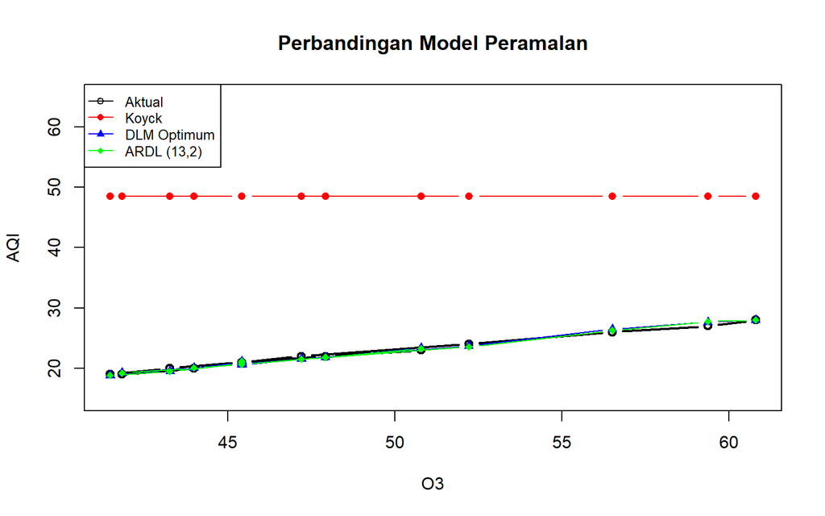

```r
par(mfrow=c(1,1))

plot(test$o3, test$AQI, type="b", col="black", ylim=c(15,65), lwd=2, pch=1, ylab="AQI", xlab="O3", main="Perbandingan Model Peramalan")

lines(test$o3, fore.koyck$mean, col="red", type="b", pch=16)
lines(test$o3, fore.dlm.opt$forecasts, col="blue", type="b", pch=17)
lines(test$o3, fore.ardl.opt$forecasts, col="green", type="b", pch=18)

legend("topleft", legend=c("Aktual", "Koyck", "DLM Optimum", "ARDL (13,2)"), col=c("black","red","blue","green"), lty=1, pch=c(1,16,17,18), cex=0.8)
```